# US coal exports

Joey Schechter and Devin Bunch

26 April 2021

## Preliminaries:

### Load libraries

It’s a good idea to load your libraries at the top of the Rmd document so that everyone can see what you’re using. Similarly, it’s good practice to set `cache=FALSE` to ensure that the libraries are dynamically loaded each time you knit the document.

*Hint: I’ve only added the libraries needed to download and read the data. You’ll need to load additional libraries to complete this assignment. Add them here once you discover that you need them.*

```r
## Install the pacman package if necessary
if (!require("pacman")) install.packages("pacman")
## Install other packages using pacman::p_load()
pacman::p_load(httr, readxl, here,tinytex,tidyverse,data.table,rlang,
               ggplot2, janitor, tidyfast, dtplyr, microbenchmark, skimr, lubridate, ggiraph,naniar,dtplyr)
```

### Read in the data

Use `httr::GET()` to fetch the EIA excel file for us from web. (We’ll learn more about `httr`, GET and other HTTP methods when we get to webscraping next week.)

```r
# library(here) ## Already loaded
# library(httr) ## Already loaded
url = "https://www.eia.gov/coal/archive/coal_historical_exports.xlsx"
## Only download the file if we need to
if(!file.exists(here::here("data/coal.xlsx"))) {
  GET(url, write_disk(here::here("data/coal.xlsx")))
}
```

Next, we read in the file.

```r
coal = read_excel(here::here("data/coal.xlsx"), skip = 3, na = ".")
```

We are now ready to go.

## 1) Clean the column names

The column (i.e. variable) names aren’t great: Spacing, uppercase letters, etc.

```r
#names(coal)

coal <- coal %>% clean_names()

names(coal)
```

```
##  [1] "year"                     "quarter"
##  [3] "type"                     "customs_district"
##  [5] "coal_origin_country"      "coal_destination_country"
##  [7] "steam_coal"               "steam_revenue"
##  [9] "metallurgical"            "metallurgical_revenue"
## [11] "total"                    "total_revenue"
## [13] "coke"                     "coke_revenue"
```

*Hint: Use either `gsub()` and regular expressions or, more simply, the `janitor()` package. You will need to install the latter first.*

## 2) Total US coal exports over time (year only)

Plot the US’s total coal exports over time by year ONLY. What secular trends do you notice in the data?

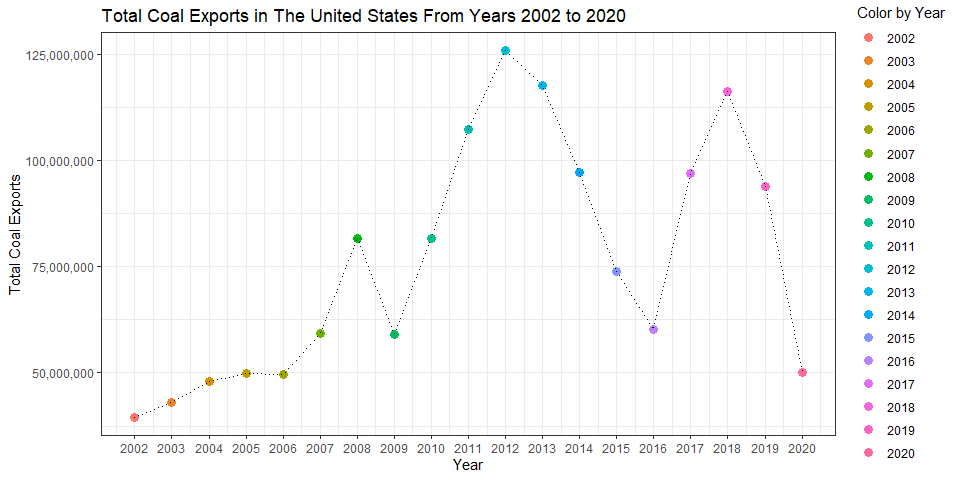

```r
#We want to group by year and put it in chronological order, using dplyr before transition from a data frame into a data table
#coal <- coal %>% group_by("year") %>% arrange(year)
#from dplyr
#coal <- coal %>% filter(coal_origin_country=="United States")

#from data.table commands, turn data frame into data table
coal = setDT(coal)

#Attempt to make a loop command for summation of totals by year
#coal[,lapply(.SD,sum,na.rm=T),.SDcols=c("total"), by = year]

#Using our data.table package, we have filtered out other countries(subset just includes US data), grouped by year, and have created a variable for sum totals of coal exports
coal[coal_origin_country=="United States" & order(year),sum_total:=sum(total, na.rm=T), by=year]

#Now we can use ggplot to display our data, and add customization
ggplot(data = coal, aes(x = year, y = sum_total)) + scale_y_continuous(labels = scales::comma) + geom_point(aes(color = factor(year)), size = 3) + labs(title= "Total Coal Exports in The United States From Years 2002 to 2020", x = "Year", y = "Total Coal Exports", color = "Color by Year") + geom_line(linetype="dotted", size = 0.5) + theme_bw() + scale_x_continuous(breaks = seq(2002, 2020, 1))
```

```r
#Look at our summary
summary(coal)
```

```
##       year         quarter         type           customs_district
##  Min.   :2002   Min.   :1.00   Length:10839       Length:10839
##  1st Qu.:2008   1st Qu.:2.00   Class :character   Class :character
##  Median :2012   Median :2.00   Mode  :character   Mode  :character
##  Mean   :2011   Mean   :2.49
##  3rd Qu.:2016   3rd Qu.:3.00
##  Max.   :2020   Max.   :4.00
##
##  coal_origin_country coal_destination_country   steam_coal
##  Length:10839        Length:10839             Min.   :      1
##  Class :character    Class :character         1st Qu.:     49
##  Mode  :character    Mode  :character         Median :    390
##                                               Mean   :  76691
##                                               3rd Qu.:  53656
##                                               Max.   :5469837
##                                               NA's   :2967
##  steam_revenue       metallurgical     metallurgical_revenue     total
##  Min.   :     2505   Min.   :      8   Min.   :     2510     Min.   :      1
##  1st Qu.:    13298   1st Qu.:  54069   1st Qu.:  4874344     1st Qu.:     88
##  Median :    64882   Median : 132277   Median : 14300438     Median :   5709
##  Mean   :  4642737   Mean   : 253546   Mean   : 30266043     Mean   : 149568
##  3rd Qu.:  3192905   3rd Qu.: 353636   3rd Qu.: 38596104     3rd Qu.: 138465
##  Max.   :183430606   Max.   :3054129   Max.   :481900685     Max.   :5477286
##  NA's   :2967        NA's   :7498      NA's   :7498          NA's   :1139
##  total_revenue            coke           coke_revenue        sum_total
##  Min.   :     2505   Min.   :     1.0   Min.   :    2527   Min.   : 39601241
##  1st Qu.:    19738   1st Qu.:    22.0   1st Qu.:   10742   1st Qu.: 59096951
##  Median :   444718   Median :   109.5   Median :   33130   Median : 81519115
##  Mean   : 14192420   Mean   :  9846.6   Mean   : 1569972   Mean   : 81439118
##  3rd Qu.: 11647034   3rd Qu.:  3769.0   3rd Qu.:  677451   3rd Qu.:107258561
##  Max.   :529486058   Max.   :218986.0   Max.   :41625090   Max.   :125745662
##  NA's   :1139        NA's   :8635       NA's   :8635
```

*Hints: If you want nicely formatted y-axis label, add `+ scale_y_continuous(labels = scales::comma)` to your `ggplot2` code.*

## 3) Total US coal exports over time (year AND quarter)

Now do the same as the above, expect aggregated quarter of year (2001Q1, 2002Q2, etc.). Do you notice any seasonality that was masked from the yearly averages?

```r
#So as to not lose our data.table for coal in #1, we must create a copy from our data.table package and use that data.table
coal_dt = copy(coal)

#Now we want to factor in quarter of the year

#Now we want to factor in quarter of the year
coal_dt[order(year)]
```

```
##        year quarter         type customs_district coal_origin_country
##     1: 2002       1 Coal Exports    Anchorage, AK       United States
##     2: 2002       1 Coal Exports    Baltimore, MD       United States
##     3: 2002       1 Coal Exports    Baltimore, MD       United States
##     4: 2002       1 Coal Exports    Baltimore, MD       United States
##     5: 2002       1 Coal Exports    Baltimore, MD       United States
##    ---
## 10835: 2020       3 Coal Exports      Seattle, WA       United States
## 10836: 2020       3 Coal Exports      Seattle, WA       United States
## 10837: 2020       3 Coal Exports   St. Albans, VT       United States
## 10838: 2020       3 Coal Exports        Tampa, FL       United States
## 10839: 2020       3 Coal Exports        Tampa, FL       United States
##               coal_destination_country steam_coal steam_revenue metallurgical
##     1: South Korea (Republic of Korea)      66874       1669556            NA
##     2:                         Belgium     125856       3703190            NA
```

[output cut: 21 more lines]

```r
coal_dt$yearqt <- paste(coal_dt$year,coal_dt$quarter)

coal_dt[,sum_total:=sum(total,na.rm=T),by=yearqt]

coal_dt
```

```
##        year quarter         type customs_district coal_origin_country
##     1: 2002       1 Coal Exports    Anchorage, AK       United States
##     2: 2002       1 Coal Exports    Baltimore, MD       United States
##     3: 2002       1 Coal Exports    Baltimore, MD       United States
##     4: 2002       1 Coal Exports    Baltimore, MD       United States
##     5: 2002       1 Coal Exports    Baltimore, MD       United States
##    ---
## 10835: 2020       3 Coal Exports      Seattle, WA       United States
## 10836: 2020       3 Coal Exports      Seattle, WA       United States
## 10837: 2020       3 Coal Exports   St. Albans, VT       United States
## 10838: 2020       3 Coal Exports        Tampa, FL       United States
## 10839: 2020       3 Coal Exports        Tampa, FL       United States
##               coal_destination_country steam_coal steam_revenue metallurgical
##     1: South Korea (Republic of Korea)      66874       1669556            NA
##     2:                         Belgium     125856       3703190            NA
```

[output cut: 33 more lines]

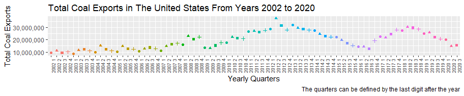

```r
cols <- as.character(coal_dt$yearqt)

#NOW, we again want to make a scatter plot of our data using ggplot
#Note the (fig.width and fig.height code in  this r chunk that makes this display so nicley
ggplot(data=coal_dt, aes(y=sum_total, x=yearqt)) + labs(title= "Total Coal Exports in The United States From Years 2002 to 2020", x = "Yearly Quarters", y = "Total Coal Exports", color = "Color by Quarter in Sequence", caption = "The quarters can be defined by the last digit after the year") + geom_point(aes(x=yearqt, y=sum_total, color = factor(year), shape = factor(quarter)), show.legend = FALSE)  + scale_y_continuous(labels = scales::comma) + theme(axis.text.x = element_text(angle=90,size=7))
```

*Hint: ggplot2 is going to want you to convert your quarterly data into actual date format before it plots nicely. (i.e. Don’t leave it as a string.)*

**There was definitely seasonality that was masked from the yearly averages. We can see this because there exists more variation and more cycles within the given time period. This is likely due to the fact that the yearly totals were summations of the quarters, which cuts out the ability to see more than one trend in a given year. From our more detailed data display, we can see more secular trends, and more variation among the annual exports. Looking at the shape pattern, we see the triangles that signify a second quarter of a year, are mostly the times when exports reach their highest each year: the second quarter receives the most coal exports in the given year. We also see the oscillation periods getting wider, signifying an export activity level that increases as time goes on.**

## 4) Exports by destination country

### 4.1) Create a new data frame

Create a new data frame called `coal_country` that aggregates total exports by destination country (and quarter of year). Make sure you print the resulting data frame so that it appears in the knitted R markdown document.

```r
#So as to not lose our data.table for coal in #1 or #2, we must create a copy from our data.table package and use that new data.table
coal_country = copy(coal)

#coal_country[,,by=coal_destination_country]

#Now we want to aggregate total exports by destination country and quarter of year
#so do the same steps as in 2 first
coal_country[order(year)]
```

```
##        year quarter         type customs_district coal_origin_country
##     1: 2002       1 Coal Exports    Anchorage, AK       United States
##     2: 2002       1 Coal Exports    Baltimore, MD       United States
##     3: 2002       1 Coal Exports    Baltimore, MD       United States
##     4: 2002       1 Coal Exports    Baltimore, MD       United States
##     5: 2002       1 Coal Exports    Baltimore, MD       United States
##    ---
## 10835: 2020       3 Coal Exports      Seattle, WA       United States
## 10836: 2020       3 Coal Exports      Seattle, WA       United States
## 10837: 2020       3 Coal Exports   St. Albans, VT       United States
## 10838: 2020       3 Coal Exports        Tampa, FL       United States
## 10839: 2020       3 Coal Exports        Tampa, FL       United States
##               coal_destination_country steam_coal steam_revenue metallurgical
##     1: South Korea (Republic of Korea)      66874       1669556            NA
##     2:                         Belgium     125856       3703190            NA
```

[output cut: 21 more lines]

```r
#make our quarterly variable
coal_country$yearqt <- paste(coal_country$year,coal_country$quarter)

#now our data is summed according to the destination country
coal_country[,sum_total:=sum(total,na.rm=T),by= coal_destination_country]

names(coal_country$coal_destination_country)
```

```r
#but now we need to sum the sum_total variable to get it differentiated by quarters: sum(sum_total)
coal_country[,summed_total:=sum(sum_total,na.rm=T),by= coal_destination_country]

coal_country[,order(yearqt), by=coal_destination_country]
```

```
##               coal_destination_country V1
##     1: South Korea (Republic of Korea)  1
##     2: South Korea (Republic of Korea)  2
##     3: South Korea (Republic of Korea)  3
##     4: South Korea (Republic of Korea)  4
##     5: South Korea (Republic of Korea)  5
##    ---
## 10835:                         Senegal  9
## 10836:   Fedrated States of Micronesia  1
## 10837:                   Western Samoa  1
## 10838:                        Anguilla  1
## 10839:                          Guinea  1
```

```r
#sum by country
#coal_country[order(coal_destination_country)]
#coal_country[,sum_country:=sum(sum_total,na.rm=T),by= coal_destination_country]

#ok, check to see it worked
#coal_country
#print it out
coal_country
```

```
##        year quarter         type customs_district coal_origin_country
##     1: 2002       1 Coal Exports    Anchorage, AK       United States
##     2: 2002       1 Coal Exports    Baltimore, MD       United States
##     3: 2002       1 Coal Exports    Baltimore, MD       United States
##     4: 2002       1 Coal Exports    Baltimore, MD       United States
##     5: 2002       1 Coal Exports    Baltimore, MD       United States
##    ---
## 10835: 2020       3 Coal Exports      Seattle, WA       United States
## 10836: 2020       3 Coal Exports      Seattle, WA       United States
## 10837: 2020       3 Coal Exports   St. Albans, VT       United States
## 10838: 2020       3 Coal Exports        Tampa, FL       United States
## 10839: 2020       3 Coal Exports        Tampa, FL       United States
##               coal_destination_country steam_coal steam_revenue metallurgical
##     1: South Korea (Republic of Korea)      66874       1669556            NA
##     2:                         Belgium     125856       3703190            NA
```

[output cut: 33 more lines]

### 4.2) Inspect the data frame

It looks like some countries are missing data for a number of years and periods (e.g. Albania). Confirm that this is the case. What do you think is happening here?

```r
#we can compare rows and column with the original data.table set (not the copy) to see which variable inputs are missing

#first let us look at
#names(coal_country$coal_destination_country)
anyNA(coal_country$total)
```

```
## [1] TRUE
```

```r
#well, let's just confirm this is the case
```

**Certain country’s are getting omitted from our data.table because we need complete data on BOTH yearly quarter AND destination country in order to group by both objects. We removed NA values in our data sets when calculating sum totals. Since each country destination has multiple coal exports in a given quarter, we will have repeat amounts for our variable “summed_total” when looking at rows of JUST one destination country and one summed_total. Our function to check if any NA observations exist within our new data.table, and when we ran our check, it shows us an output of “TRUE,” indicating there exists missing observations.**

### 4.3) Complete the data frame

Fill in the implicit missing values, so that each country has a representative row for every year-quarter time period. In other words, you should modify the data frame so that every destination country has row entries for all possible year-quarter combinations (from 2002Q1 through the most recent quarter). Order your updated data frame by country, year and, quarter.

```r
coal_country$total_clean <- coal_country$total

coal_country$total_ms <- 0

coal_country$total_ms[is.na(coal_country$total)] <- 1

coal_country$total_clean[coal_country$total_ms==1] <-
  mean(coal_country$total[coal_country$total_ms==0])

coal_country
```

```
##        year quarter         type customs_district coal_origin_country
##     1: 2002       1 Coal Exports    Anchorage, AK       United States
##     2: 2002       1 Coal Exports    Baltimore, MD       United States
##     3: 2002       1 Coal Exports    Baltimore, MD       United States
##     4: 2002       1 Coal Exports    Baltimore, MD       United States
##     5: 2002       1 Coal Exports    Baltimore, MD       United States
##    ---
## 10835: 2020       3 Coal Exports      Seattle, WA       United States
## 10836: 2020       3 Coal Exports      Seattle, WA       United States
## 10837: 2020       3 Coal Exports   St. Albans, VT       United States
## 10838: 2020       3 Coal Exports        Tampa, FL       United States
## 10839: 2020       3 Coal Exports        Tampa, FL       United States
##               coal_destination_country steam_coal steam_revenue metallurgical
##     1: South Korea (Republic of Korea)      66874       1669556            NA
##     2:                         Belgium     125856       3703190            NA
```

[output cut: 33 more lines]

*Hints: See `?tidyr::complete()` for some convenience options. Again, don’t forget to print `coal_country` after you’ve updated the data frame so that I can see the results.*

### 4.4 Some more tidying up

In answering the previous question, you *may* encounter a situation where the data frame contains a quarter — probably 2021q1 — that is missing total export numbers for *all* countries. Did this happen to you? Filter out the completely missing quarter if so. Also: Why do you think this might have happened? (Please answer the latter question even if it didn’t happen to you.)

**Though this did not happen to us in our imputation, it is entirely possible that other groups, in their attempts to fill in the gaps in their data, forgot to create a copy of their data.table or data frame. This resulted in an override several times over of certain sets of observations. When using dplyr’s data.frame’s versus DataTable’s data.table, you have to switch formats on your data set in order to use their corresponding package. When data.table is used in conjunction with multiple steps, and multiple variable manipulation, it is imperative we create copies of our data in order to keep the original data set as it was imported. Otherwise, deletions,mutations, and other changes will permanently alter the observation values. So if this was not done correctly, we would be overwriting our “total” variable, and summing it up in an aggregated way, such that certain countries for certain quarters would be accidentally ommitted, and thus formatted odd. I think the way we formatted our data is professional and it works–we did not have any troubles like stated above.**

### 4.5) Culmulative top 10 US coal export destinations

```r
#create our vector
coal10_df <- copy(coal_country)

coal10_df[,sum_country := sum(total_clean),by=coal_destination_country]
#to find the first 10 inputs
#head(10)
coal10_df %>% as.data.frame()
```

[output not shown]

[output cut: 24986 more lines]

```r
n <- coal10_df %>% arrange(desc(sum_country))

#head(unique(n$coal_destination_country))

#unique(n$coal_destination_country)

#make our vector
coal10_culm <- c(unique(n$coal_destination_country) %>% head(10))

#print out vector
coal10_culm
```

```
##  [1] "Canada"                          "Netherlands"
##  [3] "Brazil"                          "India"
##  [5] "South Korea (Republic of Korea)" "United Kingdom"
##  [7] "Japan"                           "Italy"
##  [9] "Germany, Federal Republic of"    "Mexico"
```

### 4.6) Recent top 10 US coal export destinations

Now do the same, except for most recent period on record (i.e. final quarter in the dataset). Call this vector `coal10_recent` and make sure to print it so that I can see it too. Are there any interesting differences between the two vectors? Apart from any secular trends, what else might explain these differences?

```r
#now let's filter by year and quarter, and then arrange our totals by country
r <- coal10_df %>% filter(year=="2020" & quarter=="3") %>% arrange(desc(sum_country))

#convert into a data frame
r <- as.data.frame(r)

#make our vector
coal10_recent <- c(unique(r$coal_destination_country) %>% head(10))

#print out vector
coal10_recent
```

```
##  [1] "Canada"                          "Netherlands"
##  [3] "Brazil"                          "India"
##  [5] "South Korea (Republic of Korea)" "United Kingdom"
##  [7] "Japan"                           "Italy"
##  [9] "Germany, Federal Republic of"    "Mexico"
```

**From our two vectors produced, we can see that they are the exact same vectors, with the exact same arrangement of country destination names. Although they share the same top exports, we can gather that Canada is the Number 1 in most coal imports(since they’re receiving US’ coal exports). If they are typical, and regular trading partners, then we would expect to see the same trends in top export destinations. Which we did.**

Plot the quarterly coal exports over time, but now disaggregated by country. In particular, highlight the top 10 (cumulative) export destinations and then sum the remaining countries into a combined “Other” category. (In other words, your figure should contain the time series of eleven different countries/categories.)

```r
as.data.table(coal10_df)
```

```
##        year quarter         type customs_district coal_origin_country
##     1: 2002       1 Coal Exports    Anchorage, AK       United States
##     2: 2002       1 Coal Exports    Baltimore, MD       United States
##     3: 2002       1 Coal Exports    Baltimore, MD       United States
##     4: 2002       1 Coal Exports    Baltimore, MD       United States
##     5: 2002       1 Coal Exports    Baltimore, MD       United States
##    ---
## 10835: 2020       3 Coal Exports      Seattle, WA       United States
## 10836: 2020       3 Coal Exports      Seattle, WA       United States
## 10837: 2020       3 Coal Exports   St. Albans, VT       United States
## 10838: 2020       3 Coal Exports        Tampa, FL       United States
## 10839: 2020       3 Coal Exports        Tampa, FL       United States
##               coal_destination_country steam_coal steam_revenue metallurgical
##     1: South Korea (Republic of Korea)      66874       1669556            NA
##     2:                         Belgium     125856       3703190            NA
```

[output cut: 33 more lines]

```r
coal10_df[,sum_country:=sum(total_clean), by=c("coal_destination_country","yearqt")]

can <- coal10_df %>% filter(coal_destination_country=="Canada")
den <- coal10_df %>% filter(coal_destination_country=="Netherlands")
bra <- coal10_df %>% filter(coal_destination_country=="Brazil")
ind <- coal10_df %>% filter(coal_destination_country=="India")
kor <- coal10_df %>% filter(coal_destination_country=="South Korea (Republic of Korea)")
bri <- coal10_df %>% filter(coal_destination_country=="United Kingdom")
jap <- coal10_df %>% filter(coal_destination_country=="Japan")
ita <- coal10_df %>% filter(coal_destination_country=="Italy")
ger <- coal10_df %>% filter(coal_destination_country=="Germany, Federal Republic of")
mex <- coal10_df %>% filter(coal_destination_country=="Mexico")

others <- coal_country %>% filter(coal_destination_country != c("Canada","Netherlands","Brazil","India",
                                                        "South Korea (Republic of Korea)","United Kingdom",
                                                        "Japan","Italy","Germany, Federal Republic of",
                                                        "Mexico"))



can <- as.data.frame(can)
den <- as.data.frame(den)
bra <- as.data.frame(bra)
ind <- as.data.frame(ind)
kor <- as.data.frame(kor)
bri <- as.data.frame(bri)
jap <- as.data.frame(jap)
ita <- as.data.frame(ita)
ger <- as.data.frame(ger)
mex <- as.data.frame(mex)

others <- as.data.frame(others)
others <- others %>% group_by(yearqt) %>% mutate(sum_total = sum(total_clean))

can
```

[output not shown]

[output cut: 3737 more lines]

```r
mex
```

[output not shown]

[output cut: 1845 more lines]

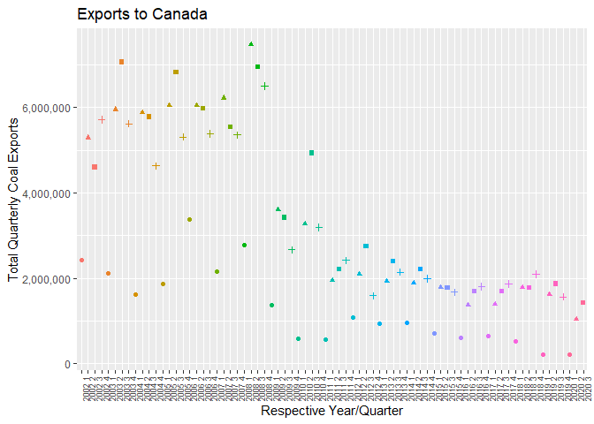

```r
ggcan <- ggplot(can,aes(yearqt,sum_country)) + geom_point(aes(x=yearqt, y=sum_country, color = factor(year), shape = factor(quarter)), show.legend = FALSE) + theme(axis.text.x = element_text(angle=90,size=7)) + scale_y_continuous(labels = scales::comma)+ ylab("Total Quarterly Coal Exports") + xlab("Respective Year/Quarter")+labs(title="Exports to Canada")

ggden <- ggplot(den,aes(yearqt,sum_country)) + geom_point(aes(color="yearqt")
) + theme(axis.text.x = element_text(angle=90,size=7)) + scale_y_continuous(labels = scales::comma)+ ylab("Total Quarterly Coal Exports") + xlab("Respective Year/Quarter")+labs(title="Exports to Netherlands")

ggbra <- ggplot(bra,aes(yearqt,sum_country)) + geom_point(aes(color="yearqt")
) + theme(axis.text.x = element_text(angle=90,size=7)) + scale_y_continuous(labels = scales::comma)+ ylab("Total Quarterly Coal Exports") + xlab("Respective Year/Quarter")+labs(title="Exports to Brazil")

ggind <- ggplot(ind,aes(yearqt,sum_country)) + geom_point(aes(color="yearqt")
) + theme(axis.text.x = element_text(angle=90,size=7)) + scale_y_continuous(labels = scales::comma)+ ylab("Total Quarterly Coal Exports") + xlab("Respective Year/Quarter")+labs(title="Exports to India")

ggkor <- ggplot(kor,aes(yearqt,sum_country)) + geom_point(aes(color="yearqt")
) + theme(axis.text.x = element_text(angle=90,size=7)) + scale_y_continuous(labels = scales::comma)+ ylab("Total Quarterly Coal Exports") + xlab("Respective Year/Quarter")+labs(title="Exports to South Korea")

ggbri <- ggplot(bri,aes(yearqt,sum_country)) + geom_point(aes(color="yearqt")
) + theme(axis.text.x = element_text(angle=90,size=7)) + scale_y_continuous(labels = scales::comma)+ ylab("Total Quarterly Coal Exports") + xlab("Respective Year/Quarter")+labs(title="Exports to United Kingdom")

ggjap <- ggplot(jap,aes(yearqt,sum_country)) + geom_point(aes(color="yearqt")
) + theme(axis.text.x = element_text(angle=90,size=7)) + scale_y_continuous(labels = scales::comma)+ ylab("Total Quarterly Coal Exports") + xlab("Respective Year/Quarter")+labs(title="Exports to Japan")

ggita <- ggplot(ita,aes(yearqt,sum_country)) + geom_point(aes(color="yearqt")
) + theme(axis.text.x = element_text(angle=90,size=7)) + scale_y_continuous(labels = scales::comma)+ ylab("Total Quarterly Coal Exports") + xlab("Respective Year/Quarter")+labs(title="Exports to Italy")

ggger <- ggplot(ger,aes(yearqt,sum_country)) + geom_point(aes(color="yearqt")
) + theme(axis.text.x = element_text(angle=90,size=7)) + scale_y_continuous(labels = scales::comma)+ ylab("Total Quarterly Coal Exports") + xlab("Respective Year/Quarter")+labs(title="Exports to Germany")

ggmex <- ggplot(mex,aes(yearqt,sum_country)) + geom_point(aes(color="yearqt")
) + theme(axis.text.x = element_text(angle=90,size=7)) + scale_y_continuous(labels = scales::comma)+labs(title="Exports to Mexico")+ ylab("Total Quarterly Coal Exports") + xlab("Respective Year/Quarter")

ggothers <- ggplot(others,aes(yearqt,sum_total)) + geom_point(aes(color="yearqt")
) + theme(axis.text.x = element_text(angle=90,size=7)) +  scale_y_continuous(labels = scales::comma) + ylab("Total Quarterly Coal Exports") + xlab("Respective Year/Quarter") +labs(title="Exports to All Other Countries")

ggcan
```

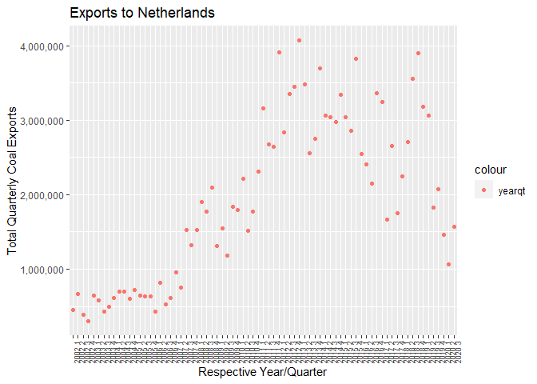

```r
ggden
```

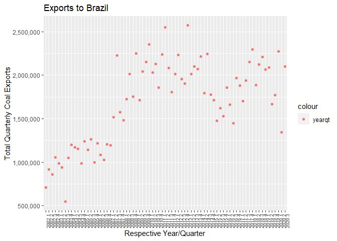

```r
ggbra
```

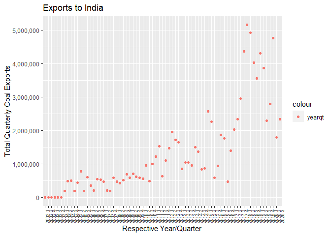

```r
ggind
```

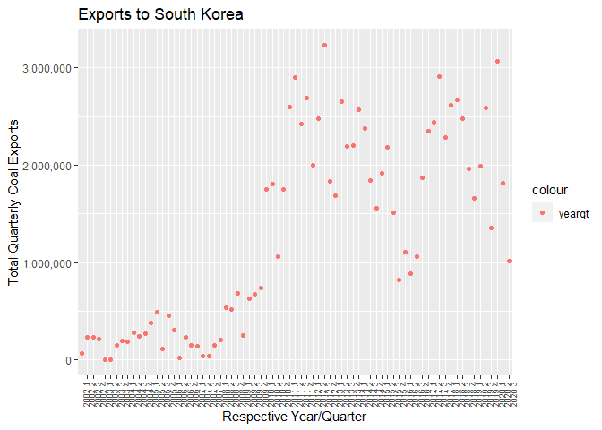

```r
ggkor
```

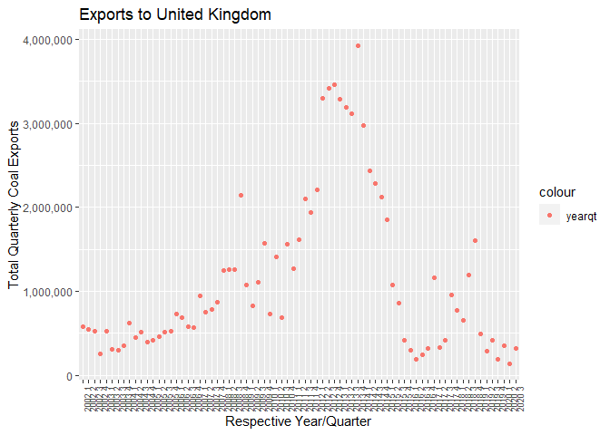

```r
ggbri
```

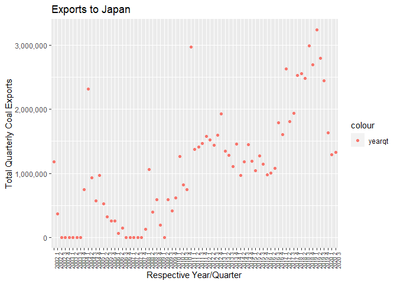

```r
ggjap
```

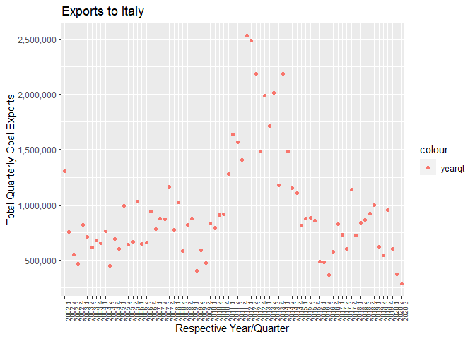

```r
ggita
```

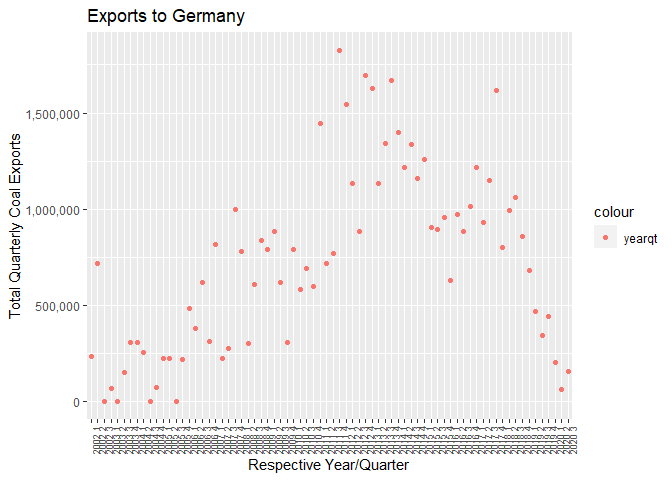

```r
ggger
```

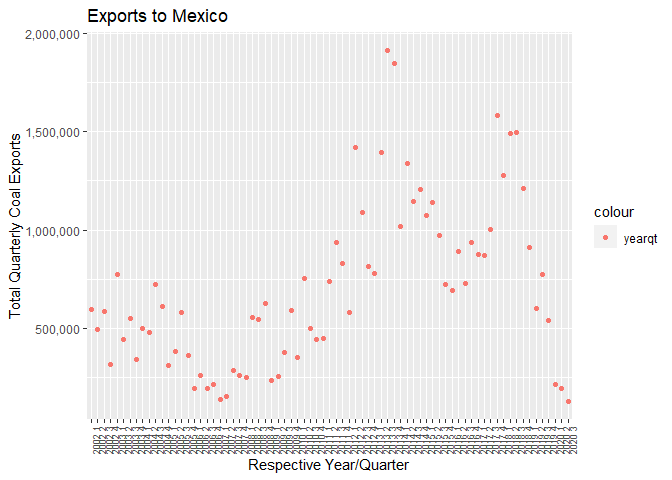

```r
ggmex
```

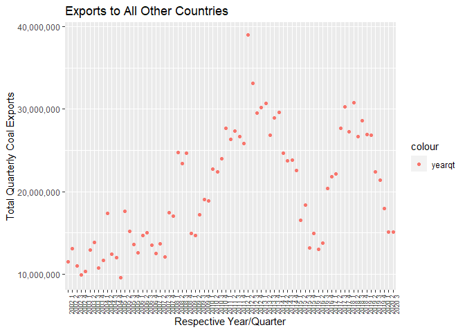

```r
ggothers
```

### 4.8) Make it pretty

Take your previous plot and add some swag to it. That is, try to make it as visually appealing as possible without overloading it with chart junk.

*Hint: You’ve got loads of options here. If you haven’t already done so, consider a more bespoke theme with the `ggthemes`, `hrbrthemes`, or `cowplot` packages. Try out `scale_fill_brewer()` and `scale_colour_brewer()` for a range of interesting colour palettes. Try some transparency effects with `alpha`. Give your axis labels more refined names with the `labs()` layer in ggplot2. While you’re at it, you might want to scale (i.e. normalise) your y-variable to get rid of all those zeros. You can shorten any country names to their ISO abbreviation; see `?countrycode::countrycode`. More substantively — but more complicated — you might want to re-order your legend (and the plot itself) according to the relative importance of the destination countries. See `?forcats::fct_reorder` or forcats::fct_relevel`.*

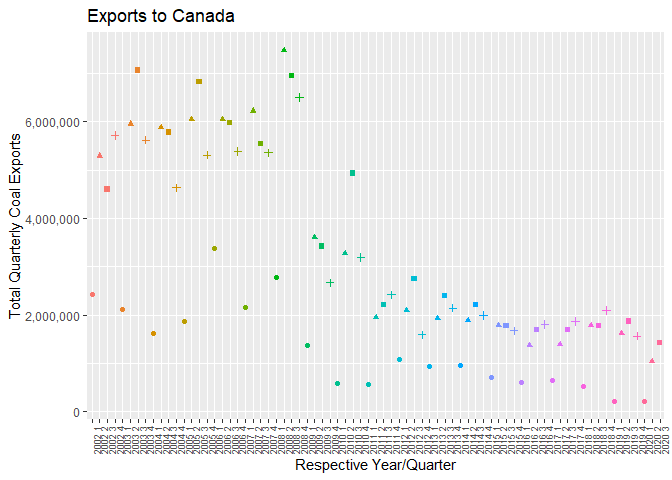

```r
ggcan <- ggplot(can,aes(yearqt,sum_country)) + geom_point(aes(x=yearqt, y=sum_country, color = factor(year), shape = factor(quarter)), show.legend = FALSE
) + theme(axis.text.x = element_text(angle=90,size=7)) + scale_y_continuous(labels = scales::comma)+ ylab("Total Quarterly Coal Exports") + xlab("Respective Year/Quarter")+labs(title="Exports to Canada")

ggden <- ggplot(den,aes(yearqt,sum_country)) + geom_point(aes(x=yearqt, y=sum_country, color = factor(year), shape = factor(quarter)), show.legend = FALSE) + theme(axis.text.x = element_text(angle=90,size=7)) + scale_y_continuous(labels = scales::comma)+ ylab("Total Quarterly Coal Exports") + xlab("Respective Year/Quarter")+labs(title="Exports to Netherlands")

ggbra <- ggplot(bra,aes(yearqt,sum_country)) + geom_point(aes(x=yearqt, y=sum_country, color = factor(year), shape = factor(quarter)), show.legend = FALSE) + theme(axis.text.x = element_text(angle=90,size=7)) + scale_y_continuous(labels = scales::comma)+ ylab("Total Quarterly Coal Exports") + xlab("Respective Year/Quarter")+labs(title="Exports to Brazil")

ggind <- ggplot(ind,aes(yearqt,sum_country)) + geom_point(aes(x=yearqt, y=sum_country, color = factor(year), shape = factor(quarter)), show.legend = FALSE) + theme(axis.text.x = element_text(angle=90,size=7)) + scale_y_continuous(labels = scales::comma)+ ylab("Total Quarterly Coal Exports") + xlab("Respective Year/Quarter")+labs(title="Exports to India")

ggkor <- ggplot(kor,aes(yearqt,sum_country)) + geom_point(aes(x=yearqt, y=sum_country, color = factor(year), shape = factor(quarter)), show.legend = FALSE
) + theme(axis.text.x = element_text(angle=90,size=7)) + scale_y_continuous(labels = scales::comma)+ ylab("Total Quarterly Coal Exports") + xlab("Respective Year/Quarter")+labs(title="Exports to South Korea")

ggbri <- ggplot(bri,aes(yearqt,sum_country)) + geom_point(aes(x=yearqt, y=sum_country, color = factor(year), shape = factor(quarter)), show.legend = FALSE
) + theme(axis.text.x = element_text(angle=90,size=7)) + scale_y_continuous(labels = scales::comma)+ ylab("Total Quarterly Coal Exports") + xlab("Respective Year/Quarter")+labs(title="Exports to United Kingdom")

ggjap <- ggplot(jap,aes(yearqt,sum_country)) + geom_point(aes(x=yearqt, y=sum_country, color = factor(year), shape = factor(quarter)), show.legend = FALSE
) + theme(axis.text.x = element_text(angle=90,size=7)) + scale_y_continuous(labels = scales::comma)+ ylab("Total Quarterly Coal Exports") + xlab("Respective Year/Quarter")+labs(title="Exports to Japan")

ggita <- ggplot(ita,aes(yearqt,sum_country)) + geom_point(aes(x=yearqt, y=sum_country, color = factor(year), shape = factor(quarter)), show.legend = FALSE
) + theme(axis.text.x = element_text(angle=90,size=7)) + scale_y_continuous(labels = scales::comma)+ ylab("Total Quarterly Coal Exports") + xlab("Respective Year/Quarter")+labs(title="Exports to Italy")

ggger <- ggplot(ger,aes(yearqt,sum_country)) + geom_point(aes(x=yearqt, y=sum_country, color = factor(year), shape = factor(quarter)), show.legend = FALSE
) + theme(axis.text.x = element_text(angle=90,size=7)) + scale_y_continuous(labels = scales::comma)+ ylab("Total Quarterly Coal Exports") + xlab("Respective Year/Quarter")+labs(title="Exports to Germany")

ggmex <- ggplot(mex,aes(yearqt,sum_country)) + geom_point(aes(x=yearqt, y=sum_country, color = factor(year), shape = factor(quarter)), show.legend = FALSE
) + theme(axis.text.x = element_text(angle=90,size=7)) + scale_y_continuous(labels = scales::comma)+labs(title="Exports to Mexico")+ ylab("Total Quarterly Coal Exports") + xlab("Respective Year/Quarter")

ggothers <- ggplot(others,aes(yearqt,sum_total)) + geom_point(aes(x=yearqt, y=sum_total, color = factor(year), shape = factor(quarter)), show.legend = FALSE
) + theme(axis.text.x = element_text(angle=90,size=7)) +  scale_y_continuous(labels = scales::comma) + ylab("Total Quarterly Coal Exports") + xlab("Respective Year/Quarter") +labs(title="Exports to All Other Countries")

ggcan
```

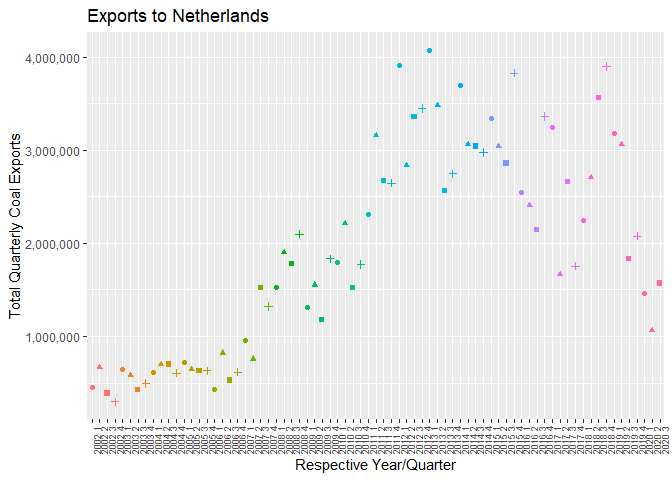

```r
ggden
```

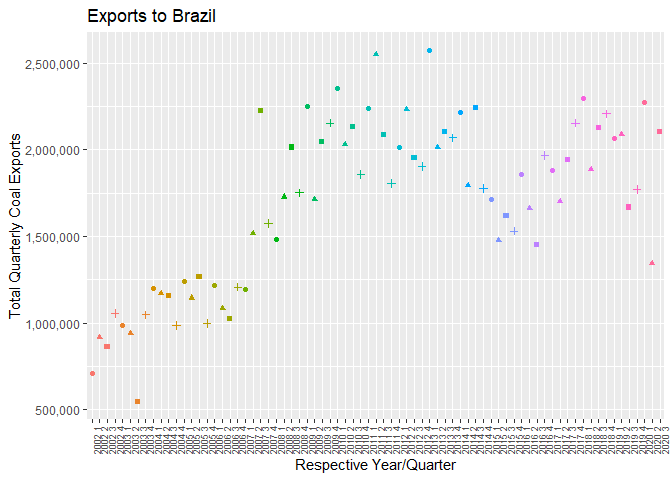

```r
ggbra
```

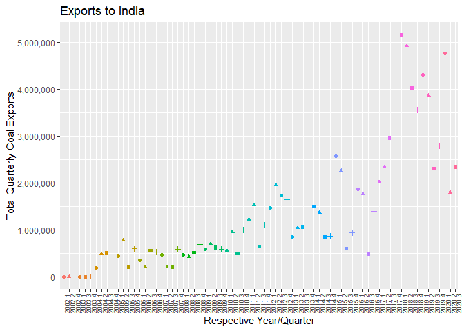

```r
ggind
```

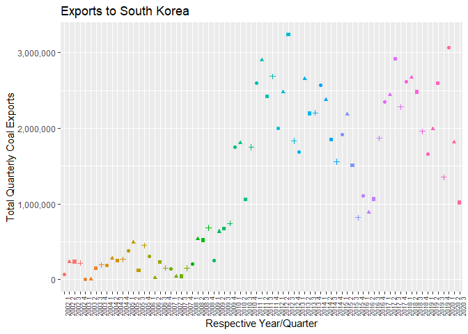

```r
ggkor
```

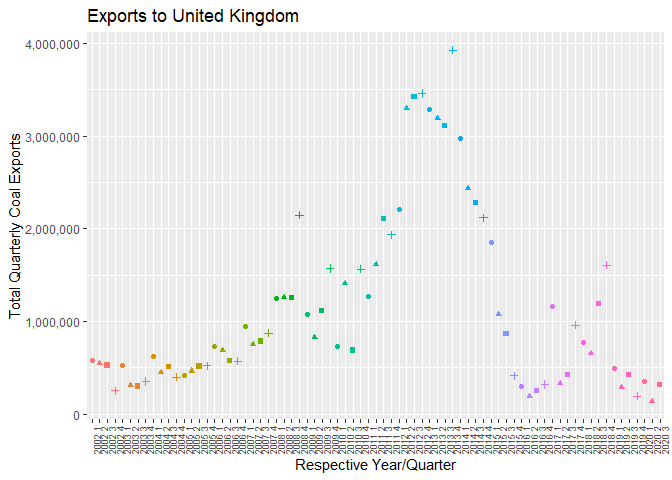

```r
ggbri
```

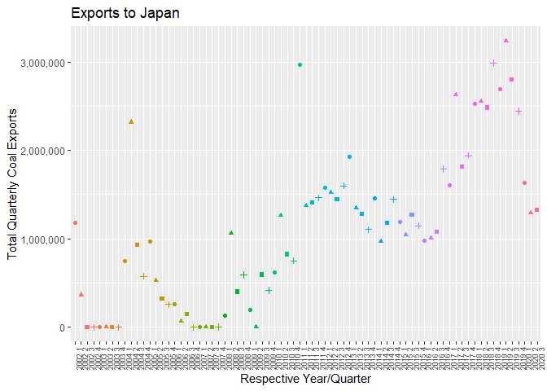

```r
ggjap
```

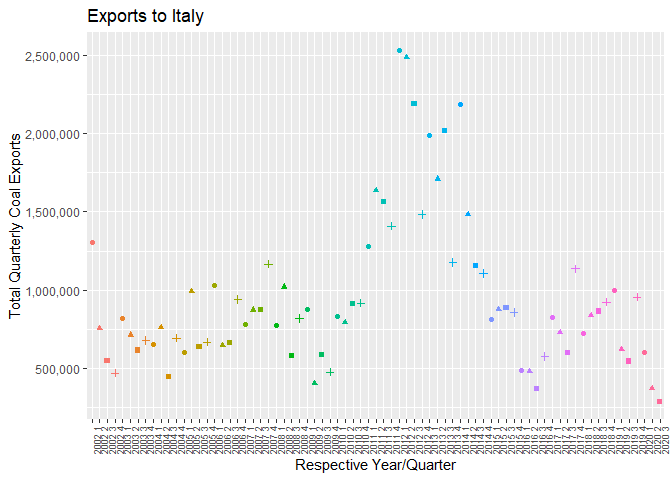

```r
ggita
```

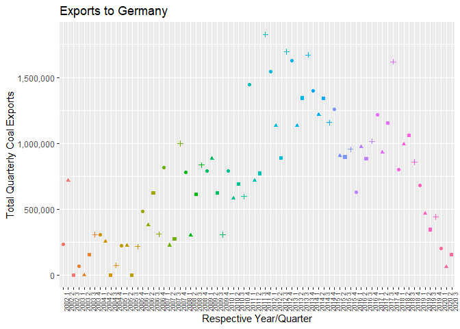

```r
ggger
```

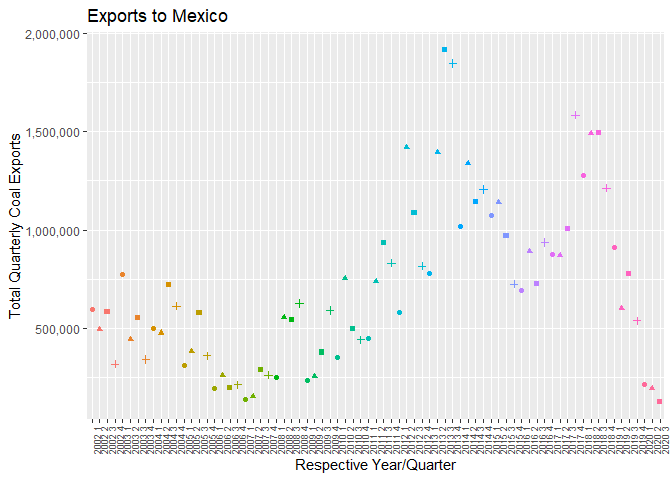

```r
ggmex
```

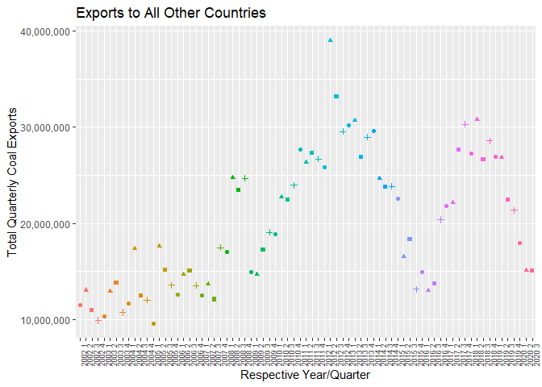

```r
ggothers
```

### 4.9) Make it interactive

Create an interactive version of your previous figure.

[figure not shown]

```r
#load extra, new package needed
p_load(gganimate, gifski)

#From our variable assignments, we can add our animations
ani1 <- ggcan + transition_states(yearqt, transition_length = 2,
state_length = 1)
ani2 <- ggden + transition_states(yearqt, transition_length = 2,
state_length = 1)
ani3 <- ggbra + transition_states(yearqt, transition_length = 2,
state_length = 1)
ani4 <- ggind + transition_states(yearqt, transition_length = 2,
state_length = 1)
ani5 <- ggkor + transition_states(yearqt, transition_length = 2,
state_length = 1)
ani6 <- ggbri + transition_states(yearqt, transition_length = 2,
state_length = 1)
ani7 <- ggjap + transition_states(yearqt, transition_length = 2,
state_length = 1)
ani8<- ggita + transition_states(yearqt, transition_length = 2,
state_length = 1)
ani9 <- ggger + transition_states(yearqt, transition_length = 2,
state_length = 1)
ani10 <- ggmex + transition_states(yearqt, transition_length = 2,
state_length = 1)
ani11 <- ggothers + transition_states(yearqt, transition_length = 2,
state_length = 1)

#animate
ani1
ani2
ani3
ani4
ani5
ani6
ani7
ani8
ani9
ani10
ani11
```

*Hint: Take a look at plotly::ggplotly(), or the gganimate package.*

## 5) Show me something interesting

There’s a lot still to explore with this data set. Your final task is to show me something interesting. Drill down into the data and explain what’s driving the secular trends that we have observed above. Or highlight interesting seasonality within a particular country. Or go back to the original `coal` data frame and look at exports by customs district, or by coal type. Do we changes or trends there? Etcetera. Etcetera. My only requirement is that you show your work and tell me what you have found.

```r
#ok,let's load our original, unclean data
coal_fun <- copy(coal)

#we have various columns of variables and rows of coresponding
#observations we have not looked at. Let's do that now

#start by looking at variable names
names(coal_fun)
```

```
##  [1] "year"                     "quarter"
##  [3] "type"                     "customs_district"
##  [5] "coal_origin_country"      "coal_destination_country"
##  [7] "steam_coal"               "steam_revenue"
##  [9] "metallurgical"            "metallurgical_revenue"
## [11] "total"                    "total_revenue"
## [13] "coke"                     "coke_revenue"
## [15] "sum_total"
```

**Starting by looking at the variable names, we wanted to see if anything other than “total,” “exports,” or “revenue.” These three variables are what we have worked with for each problem above, and what seem obvious factors into secular trends that we see in our displayed figures. We found the variables surrounding “metallurgy” concerning the branch of science and technology concerned with the properties of metals and their production and purification. Upon further research into how this affects total coal exports, we found the reason for both metallurgical variables *and* for our supposedly random “coke” variables. Here is what we found:** > **Metallurgical coal or coking coal is a grade of coal that can be used > to produce good-quality coke. Coke is an essential fuel and reactant in > the blast furnace process for primary steel making. The demand for > metallurgical coal is highly coupled to the demand for steel.**

**This tells us the two variables are correlated, and thus, we shall dive deeper into these factors (coke, metallurgical) influencing coal export levels, following below**

```r
#let's skim these columns and see what observations we've got
coal_fun$metallurgical %>% head(15)
```

```
##  [1]    NA    NA 44924    NA 83010    NA    NA    NA    NA    NA    NA    NA
## [13]    NA  1052    NA
```

```r
coal_fun$metallurgical_revenue %>% head(15)
```

```
##  [1]      NA      NA 2237029      NA 2918079      NA      NA      NA      NA
## [10]      NA      NA      NA      NA   36641      NA
```

```r
#now for coke,
coal_fun$coke_revenue %>% head(15)
```

```
##  [1]      NA      NA      NA      NA      NA      NA      NA      NA      NA
## [10]      NA      NA      NA  281700 9272887  509105
```

```r
coal_fun$coke %>% head(15)
```

```
##  [1]    NA    NA    NA    NA    NA    NA    NA    NA    NA    NA    NA    NA
## [13]   622 77021  2209
```

```r
#There are a lot of NA values being shown here

#However, let us just look at total coal exports by the amount of
#metallurgical_revenue. If this yields weird results, we can mean impute
#the NAs

#to do this, we first need to repeat our time controls steps
coal_fun[order(year)]
```

```
##        year quarter         type customs_district coal_origin_country
##     1: 2002       1 Coal Exports    Anchorage, AK       United States
##     2: 2002       1 Coal Exports    Baltimore, MD       United States
##     3: 2002       1 Coal Exports    Baltimore, MD       United States
##     4: 2002       1 Coal Exports    Baltimore, MD       United States
##     5: 2002       1 Coal Exports    Baltimore, MD       United States
##    ---
## 10835: 2020       3 Coal Exports      Seattle, WA       United States
## 10836: 2020       3 Coal Exports      Seattle, WA       United States
## 10837: 2020       3 Coal Exports   St. Albans, VT       United States
## 10838: 2020       3 Coal Exports        Tampa, FL       United States
## 10839: 2020       3 Coal Exports        Tampa, FL       United States
##               coal_destination_country steam_coal steam_revenue metallurgical
##     1: South Korea (Republic of Korea)      66874       1669556            NA
##     2:                         Belgium     125856       3703190            NA
```

[output cut: 21 more lines]

```r
#make our quarterly variable
coal_fun$yearqt <- paste(coal_fun$year,coal_fun$quarter)

#done with this chunk
```

**There exists an extreme amount of NAs here–which seems incredibly unreliable. As much as the logic behind this was scientific, maybe let’s just replace our group_by variables with “steam_coal”? Since coke is supposedly used for steam ships, it should have an impact on total exports secular data trends.**

```r
#now our data is summed according to the "steam_coal" variable
coal_fun[,sum_total:=sum(total,na.rm=T),by= steam_coal]

#but now we need to sum the sum_total variable to get it differentiated
#by quarters: sum(sum_total)
coal_fun[,summed_total:=sum(sum_total,na.rm=T),by= steam_coal]

coal_fun[,order(yearqt), by=steam_coal]
```

```
##        steam_coal V1
##     1:      66874  1
##     2:     125856  1
##     3:         NA  1
##     4:         NA  2
##     5:         NA  3
##    ---
## 10835:       4383  1
## 10836:       7165  1
## 10837:      67614  1
## 10838:     184842  1
## 10839:     700683  1
```

```r
#print it out
coal_fun
```

```
##        year quarter         type customs_district coal_origin_country
##     1: 2002       1 Coal Exports    Anchorage, AK       United States
##     2: 2002       1 Coal Exports    Baltimore, MD       United States
##     3: 2002       1 Coal Exports    Baltimore, MD       United States
##     4: 2002       1 Coal Exports    Baltimore, MD       United States
##     5: 2002       1 Coal Exports    Baltimore, MD       United States
##    ---
## 10835: 2020       3 Coal Exports      Seattle, WA       United States
## 10836: 2020       3 Coal Exports      Seattle, WA       United States
## 10837: 2020       3 Coal Exports   St. Albans, VT       United States
## 10838: 2020       3 Coal Exports        Tampa, FL       United States
## 10839: 2020       3 Coal Exports        Tampa, FL       United States
##               coal_destination_country steam_coal steam_revenue metallurgical
##     1: South Korea (Republic of Korea)      66874       1669556            NA
##     2:                         Belgium     125856       3703190            NA
```

[output cut: 33 more lines]

**Ok, now that we have successfully created a data.table object with our new variable control, we can plot a scatter plot in ggplot to see if similarities exist between secular trends with different controls.**

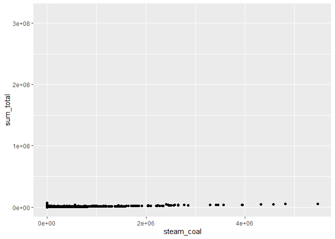

```r
#make a simple plot to see what's going on
ggplot(data=coal_fun, aes(y=sum_total, x=steam_coal)) + geom_point()
```